# Follow-up on Meeting from 20 August, 2024

AJ Fagan

23 Aug, 2024

```r
df.raw <- read.csv("../../base-data.txt")
df.raw <- df.raw %>%
  mutate(cts = exp(value) - 1) %>%
  dplyr::rename(logcts = value)
```

```r
cts <- df.raw %>%
  mutate(cts = round(cts)) %>%
  tidyr::pivot_wider(
    id_cols = "gene",
    names_from = "group",
    values_from = "cts"
  ) %>%
  data.frame(row.names = "gene")
coldata <- data.frame(
  treatment = c(rep("DMSO", 9), rep("IC50", 9), rep("IC75", 9)),
  time = rep(c(1,1,1,24,24,24,8,8,8), 3),
  group = rep(c("b", "c", "a"), 9),
  batch = rep(c("May", "May", "March"), 9)
)
coldata$time <- factor(coldata$time, levels = c(1,8,24))
coldata$treatment <- factor(coldata$treatment, levels = c("DMSO", "IC50", "IC75"))
coldata$group <- factor(coldata$group, levels = c("a", "b", "c"))
coldata$batch <- factor(coldata$batch, levels = c("March", "May"))
# coldata = t(as.matrix(coldata))

dds <- DESeqDataSetFromMatrix(
  countData = cts,
  colData = coldata,
  design = ~ treatment * time + group
)
dds <- DESeq(dds, reduced = ~ time + group, test = "LRT")
```

```r
# Format plot title
wrapper <- function(x, ...)
{
  paste(strwrap(x, ...), collapse = "\n")
}
```

# Preface

I’m copy-pasting much from the previous report to save time.

> I will put new information/changes in block quotes like this.

# Intro

Hey Mayra,

Below are (at least several of) the plots you asked for. Let me know if I missed any.

For each type of plot, I included several replicates for varying number of genes to help you pick a number to display that you like.

# Heatmap of DE between each pair of treatment groups at each time

## Ordered by $p$-value

For each pair of treatment groups, and time combination, shows the estimated log2-fold change in expression. For example, for the green-time, red-treatment, shows how much more (or less) highly expressed each gene was at 24 hours in the 45$\mu$M group compared to the 30$\mu$M group.

> Removed 45vs30 Comparison. Now the green-time, purple-treatment column shows how much more (or less) highly expressed each gene was at 24 hours in the 45$\mu$M group compared to the DMSO group.

```r
# 75 v DMSO @ 24
de.time <- data.frame(
  fc75.D.24 = results(dds, contrast = c(
                        0, # Intercept
                        0, # IC50
                        1, # IC75
                        0, # Time 8
                        0, # Time 24
                        0, # Batch b
                        0, # Batch c
                        0, # IC50 x Time 8
                        0, # IC75 x Time 8
                        0, # IC50 x Time 24
                        1  # IC75 x Time 24
                        ))$log2FoldChange
)

# 50 v DMSO @ 24
de.time$fc50.D.24 <- results(dds, contrast = c(
                        0, # Intercept
                        1, # IC50
                        0, # IC75
                        0, # Time 8
                        0, # Time 24
                        0, # Batch b
                        0, # Batch c
                        0, # IC50 x Time 8
                        0, # IC75 x Time 8
                        1, # IC50 x Time 24
                        0  # IC75 x Time 24
                        ))$log2FoldChange

# 75 v DMSO @ 8
de.time$fc75.D.8 <- results(dds, contrast = c(
                        0, # Intercept
                        0, # IC50
                        1, # IC75
                        0, # Time 8
                        0, # Time 24
                        0, # Batch b
                        0, # Batch c
                        0, # IC50 x Time 8
                        1, # IC75 x Time 8
                        0, # IC50 x Time 24
                        0  # IC75 x Time 24
                        ))$log2FoldChange
# 50 v DMSO @ 8
de.time$fc50.D.8 <- results(dds, contrast = c(
                        0, # Intercept
                        1, # IC50
                        0, # IC75
                        0, # Time 8
                        0, # Time 24
                        0, # Batch b
                        0, # Batch c
                        1, # IC50 x Time 8
                        0, # IC75 x Time 8
                        0, # IC50 x Time 24
                        0  # IC75 x Time 24
                        ))$log2FoldChange

# 75 v DMSO @ 1
de.time$fc75.D.1 <- results(dds, contrast = c(
                        0, # Intercept
                        0, # IC50
                        1, # IC75
                        0, # Time 8
                        0, # Time 24
                        0, # Batch b
                        0, # Batch c
                        0, # IC50 x Time 8
                        0, # IC75 x Time 8
                        0, # IC50 x Time 24
                        0  # IC75 x Time 24
                        ))$log2FoldChange
# 50 v DMSO @ 1
de.time$fc50.D.1 <- results(dds, contrast = c(
                        0, # Intercept
                        1, # IC50
                        0, # IC75
                        0, # Time 8
                        0, # Time 24
                        0, # Batch b
                        0, # Batch c
                        0, # IC50 x Time 8
                        0, # IC75 x Time 8
                        0, # IC50 x Time 24
                        0  # IC75 x Time 24
                        ))$log2FoldChange

rownames(de.time) <- rownames(results(dds))
de.time <- de.time[complete.cases(de.time),]

gene_ord_all <- list(
  "p" = rownames(results(dds)[order(results(dds)$padj, decreasing = F),]),
  "up" = rownames(results(dds)[order(results(dds)$log2FoldChange, decreasing = T),]),
  "down" = rownames(results(dds)[order(results(dds)$log2FoldChange, decreasing = F),]),
  'any' = rownames(results(dds)[order(abs(results(dds)$log2FoldChange), decreasing = T),])
)
gene_ord <- sapply(gene_ord_all, function(x) {
  x <- x[!is.na(results(dds)[x,"padj"]) & (results(dds)[x,"padj"] < 0.05)]
}, USE.NAMES = T, simplify = F)

de.time <- de.time[complete.cases(de.time),]


# Plot a heatmap of diff. ex
treatment.pairs <- c(
"45uM v DMSO",
"30uM v DMSO"
)
de.coldata <- data.frame(
  treatment = rep(c("45uM v DMSO", "30uM v DMSO"), 3),
  time = rep(c(24, 8, 1), each = 2)
)
rownames(de.coldata) <- colnames(de.time_p)
de.heatmap <- function(
  n,
  x = de.time,
  treatment_pairs = treatment.pairs,
  times = c(1, 8, 24),
  col_data = de.coldata,
  title_wrapper = 40,
  order_by = c("p", "up", "down", "any")
) {
  order_by <- match.arg(order_by)
  titl <- switch(order_by,
                  p = paste(
                    "Estimated log2-fold change for each treatment group at each time for the",
                    n,
                    "genes with the smallest p-value."
                  ),
                  up = paste(
                    "Estimated log2-fold change for each treatment group at each time for the",
                    n,
                    "genes with the greatest log fold-change with p<0.05."
                  ),
                  down = paste(
                    "Estimated log2-fold change for each treatment group at each time for the",
                    n,
                    "genes with the least log fold-change with p<0.05."
                  ),
                  any = paste(
                    "Estimated log2-fold change for each treatment group at each time for the",
                    n,
                    "genes with the greatest absolute log fold-change with p<0.05."
                  )

  )
  x <- x[gene_ord[[order_by]],]
  col_data <- col_data %>%
    filter(time %in% times) %>%
    mutate(time = as.factor(time)) %>%
    filter(treatment %in% treatment_pairs) %>%
    mutate(treatment = factor(treatment, ordered = T)) %>%
    #arrange(treatment) %>%
    dplyr::rename("Time (Hours)" = time) %>%
    dplyr::rename("Treatment Pair" = treatment)
  if (length(times) <= 1) {
    col_data <- col_data %>% dplyr::select(-c("Time (Hours)"))
  }
  x <- x[,colnames(x) %in% rownames(col_data)]
  pheatmap(
    as.matrix(x[1:n,]),
    annotation_col = col_data,
    cluster_rows = F, cluster_cols = F, show_colnames = F,
    legend_labels = c("Time (Hours)", "Treatment Pair"),
    main = wrapper(titl, title_wrapper),
    legend = T
  )
}
```

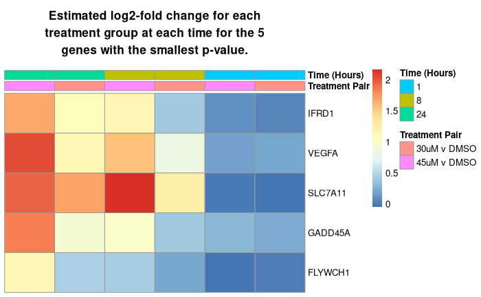

```r
de.heatmap(5)
```

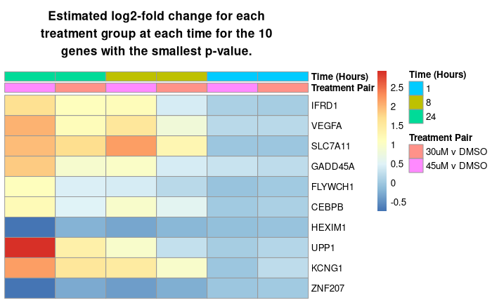

```r
de.heatmap(10)
```

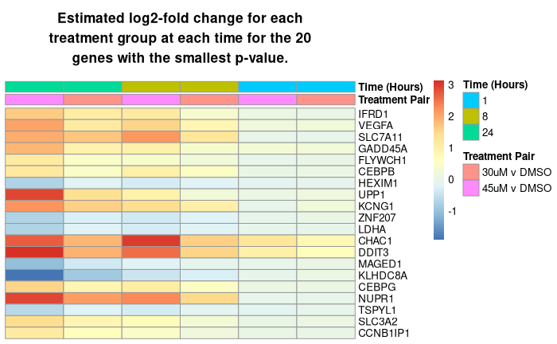

```r
de.heatmap(20)
```

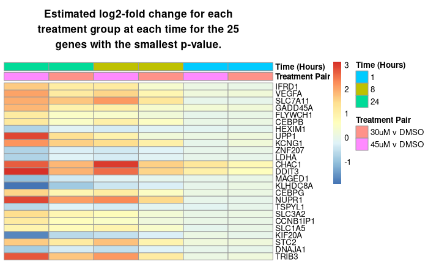

```r
de.heatmap(25)
```

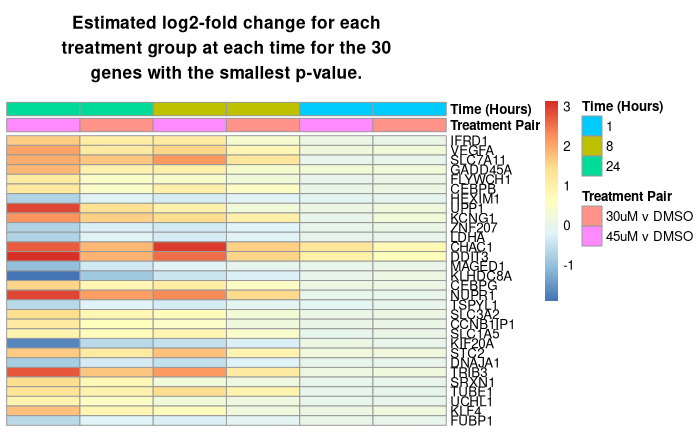

```r
de.heatmap(30)
```

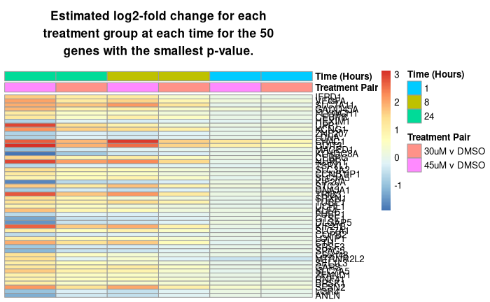

```r
de.heatmap(50)
```

## Ordered by estimated effect size, restricted to FDR-controlled $p$-value < 0.05

> Now I show essentially the same images, but now we sort them by estimated effect size at 24 hours between 45$\mu$M and DMSO. For brevity, I include only one image for each, rather than for a range of #genes, but can trivially include more, if desired.

### Ordered by decreasing log fold-change (i.e. up-regulated)

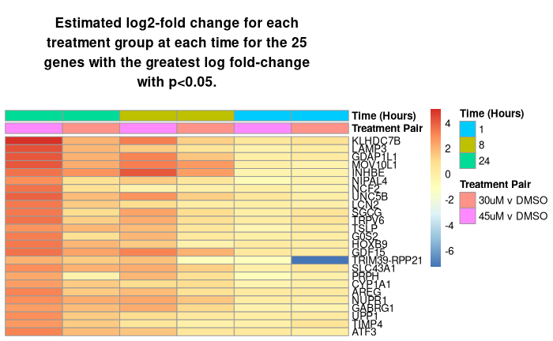

```r
de.heatmap(25, order_by = "up")
```

### Ordered by increasing log fold-change (i.e. down-regulated)

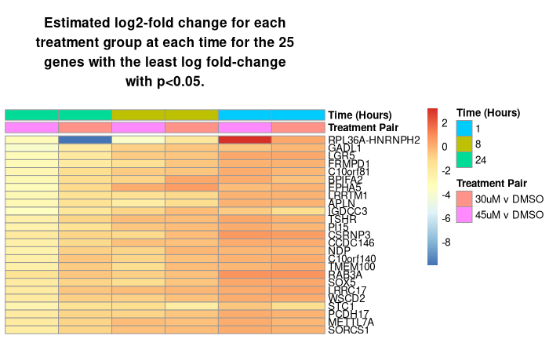

```r
de.heatmap(25, order_by="down")
```

### Ordered by decreasing abs(log fold-change) (i.e. effect far from zero)

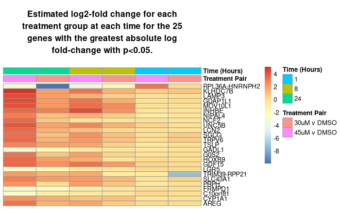

```r
de.heatmap(25, order_by="any")
```

# Barplot of DE between each pair of treatment groups at each time

## Ordered by FDR-adjusted $p$

This contains pretty much the same information as above, but in a barplot. It may be slightly easier to glean info from this, but fewer genes will fit while still looking nice.

> I also made the same changes here that I did above.

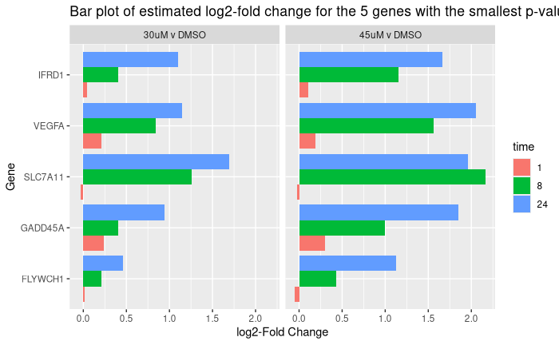

```r
genes.ordered <- factor(rownames(de.time), ordered=T)
de.time2 <- de.time
de.time2$gene <- rownames(de.time2)
de.time2 <- de.time2 %>%
  pivot_longer(-c(gene)) %>%
  mutate(treatment = de.coldata[name, "treatment"]) %>%
  mutate(time = as.factor(de.coldata[name,"time"])) %>%
  dplyr::rename(log2FoldChange = value)

de.barplot <- function(
    n,
    genes = factor(rownames(de.time)),
    x = de.time2,
    title = function(n, order_by) {
      switch(order_by,
                  p = paste(
                    "Bar plot of estimated log2-fold change for the",
                    n,
                    "genes with the smallest p-value."
                  ),
                  up = paste(
                    "Bar plot of estimated log2-fold change for the",
                    n,
                    "genes with the greatest log fold-change with p<0.05."
                  ),
                  down = paste(
                    "Bar plot of estimated log2-fold change for the",
                    n,
                    "genes with the least log fold-change with p<0.05."
                  ),
                  any = paste(
                    "Bar plot of estimated log2-fold change for the",
                    n,
                    "genes with the greatest absolute log fold-change with p<0.05."
                  )
      )
    },
    order_by = c("p", "up", "down", "any")
) {
  order_by <- match.arg(order_by)
  #print(head(de.time2 %>% filter(gene %in% gene_ord[[order_by]][1:n])))
  #print(length(unique((de.time2 %>% filter(gene %in% gene_ord[[order_by]][1:n]))$gene)))

  #print(head(de.time2 %>% filter(gene %in% gene_ord[[order_by]][1:n]) %>% filter(gene %in% genes)))
  ggplot(
    de.time2 %>% filter(gene %in% gene_ord[[order_by]][gene_ord[[order_by]] %in% genes][1:n]),
    aes(
      y = gene,
      x = log2FoldChange,
      fill = time
    )
  ) +
    geom_col(position= position_dodge(width = 0.9)) +
    facet_wrap(~treatment) +
    xlab("log2-Fold Change") +
    ylab("Gene") +
    ggtitle(wrapper(title(n, order_by))) +
    ylim(gene_ord[[order_by]][gene_ord[[order_by]] %in% genes][n:1])
}
de.barplot(5)
```

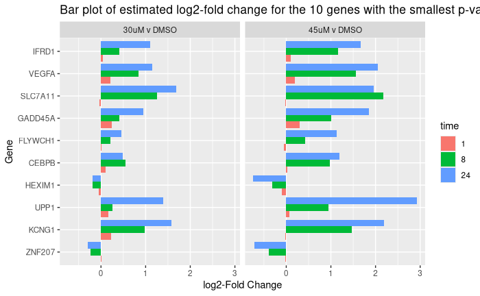

```r
de.barplot(10)
```

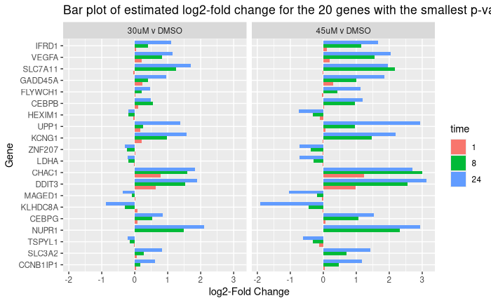

```r
de.barplot(20)
```

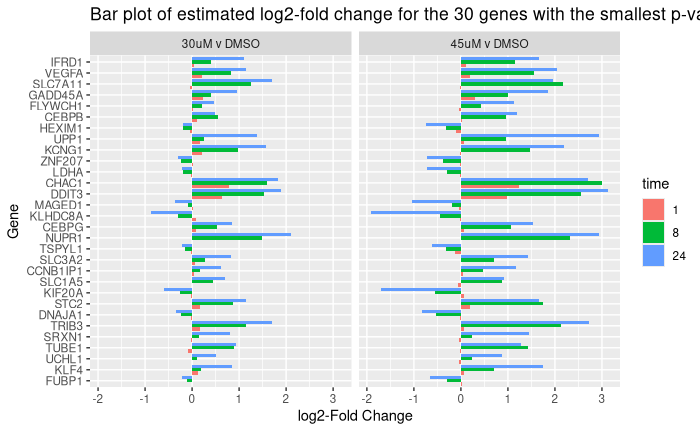

```r
de.barplot(30)
```

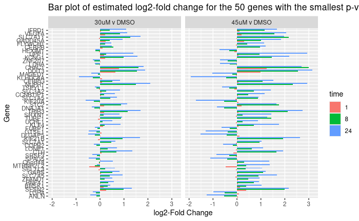

```r
de.barplot(50)
```

## Ordered by estimated effect size, restricted to FDR-controlled $p$-value < 0.05

### Ordered by decreasing log fold-change (i.e. up-regulated)

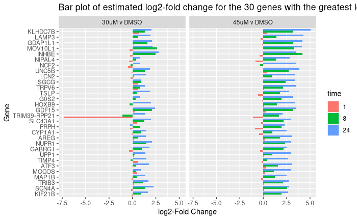

```r
de.barplot(30, order_by = 'up')
```

### Ordered by increasing log fold-change (i.e. down-regulated)

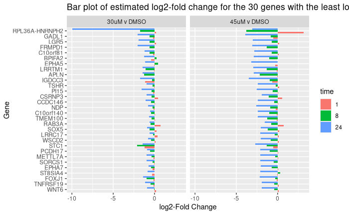

```r
de.barplot(30, order_by = 'down')
```

### Ordered by decreasing absolute log fold-change (i.e. effect far from zero)

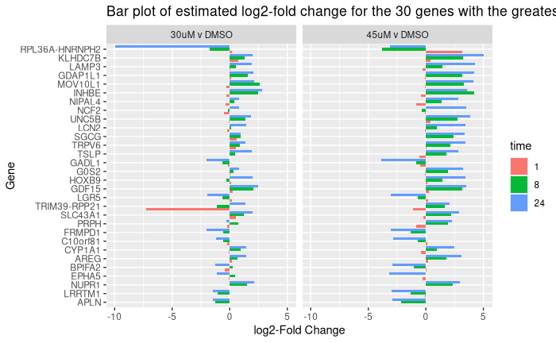

```r
de.barplot(30, order_by = 'any')
```

# Heatmap of log-counts

> I am not including this currently. Can do so upon request.

# Bar plot for ERAD genes

## Ordered by increasing $p$

This contains essentially the same info as the barplots above, but specialized to ERAD (GO:0036503) genes.

I could easily also present any of the above graphics for any given geneset.

> Only 28 genes in ERAD had p < 0.05

```r
erad.genes <- (as.data.frame(org.Hs.egALIAS2EG) %>%
  filter(gene_id %in% as.data.frame(org.Hs.egGO2ALLEGS["GO:0036503"])$gene_id) %>%
  filter(alias_symbol %in% rownames(results(dds))) %>%
  filter(alias_symbol %in% df.raw$gene))$alias_symbol
'VCP' %in% erad.genes
```

```
[1] TRUE
```

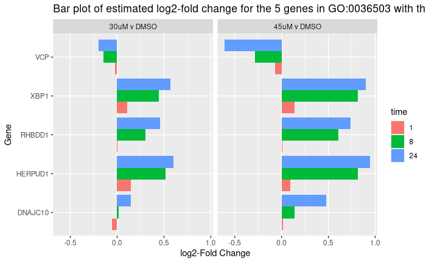

```r
de.barplot(5, genes=erad.genes, title = function(n, order_by) {paste(
  "Bar plot of estimated log2-fold change for the",
  n,
  "genes in GO:0036503 with the lowest p-value."
)})
```

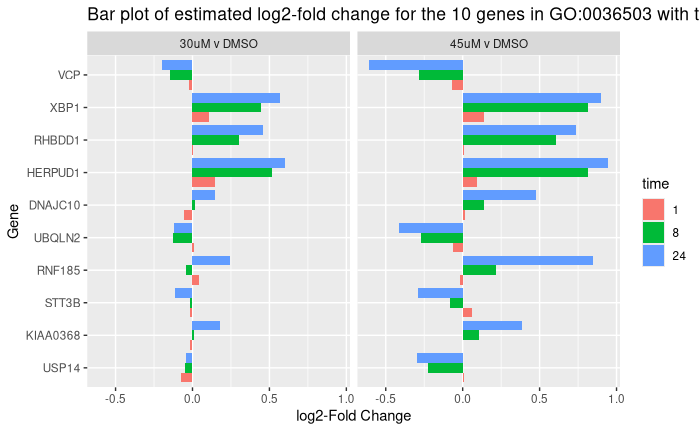

```r
de.barplot(10, genes=erad.genes, title = function(n, order_by) {paste(
  "Bar plot of estimated log2-fold change for the",
  n,
  "genes in GO:0036503 with the lowest p-value."
)})
```

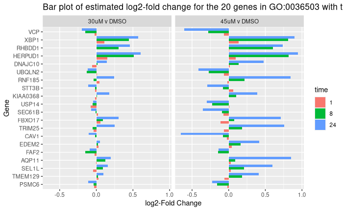

```r
de.barplot(20, erad.genes, title = function(n, order_by) {paste(
  "Bar plot of estimated log2-fold change for the",
  n,
  "genes in GO:0036503 with the lowest p-value."
)})
```

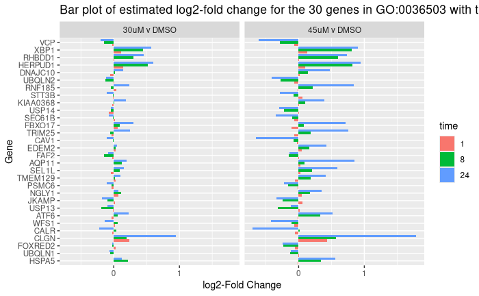

```r
de.barplot(30, erad.genes, title = function(n, order_by) {paste(
  "Bar plot of estimated log2-fold change for the",
  n,
  "genes in GO:0036503 with the lowest p-value."
)})
```

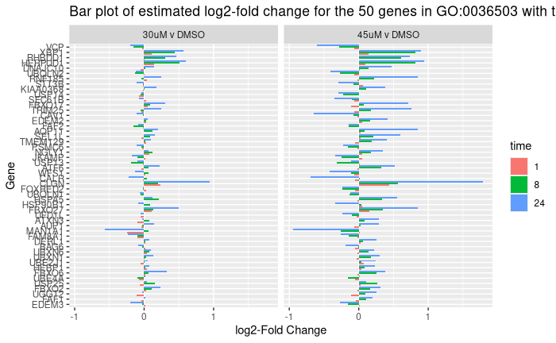

```r
de.barplot(50, erad.genes, title = function(n, order_by) {paste(
  "Bar plot of estimated log2-fold change for the",
  n,
  "genes in GO:0036503 with the lowest p-value."
)})
```